# 06. 광고, 정말 효과가 있을까_

```r
library(readxl)
```

```r
adver = read_xlsx("C:/Users/이찬솔/Desktop/숭실/R/실무 예제/abtest.xlsx", sheet = 1)
dim(adver)
```

```
## [1] 43968     9
```

```r
head(adver)
```

```
## # A tibble: 6 x 9
##   city1  city2    age sex   type     open click conversion sales
##   <chr>  <chr>  <dbl> <chr> <chr>   <dbl> <dbl>      <dbl> <chr>
## 1 강원도 강릉시    18 man   A_GROUP  1503     6          0 NA
## 2 강원도 강릉시    19 man   A_GROUP  2314    44          1 NA
## 3 강원도 강릉시    20 man   A_GROUP  1978    11          0 NA
## 4 강원도 강릉시    21 man   A_GROUP  1821    18          0 0
## 5 강원도 강릉시    22 man   A_GROUP  2204    40          2 21180
## 6 강원도 강릉시    23 man   A_GROUP  2229    12          0 0
```

- 결측값 제거

```r
adver <- adver[adver$sales != "NA",]
adver$sales = as.numeric(adver$sales)
```

```r
summary(adver)
```

```
##     city1              city2                age            sex
##  Length:40304       Length:40304       Min.   :18.00   Length:40304
##  Class :character   Class :character   1st Qu.:30.00   Class :character
##  Mode  :character   Mode  :character   Median :41.00   Mode  :character
##                                        Mean   :41.05
##                                        3rd Qu.:52.00
##                                        Max.   :65.00
##      type                open           click          conversion
##  Length:40304       Min.   :    7   Min.   :  0.00   Min.   : 0.000
##  Class :character   1st Qu.:  340   1st Qu.:  3.00   1st Qu.: 0.000
##  Mode  :character   Median : 1318   Median : 13.00   Median : 0.000
##                     Mean   : 2451   Mean   : 36.74   Mean   : 1.481
##                     3rd Qu.: 3380   3rd Qu.: 45.00   3rd Qu.: 1.000
##                     Max.   :15166   Max.   :589.00   Max.   :51.000
##      sales
##  Min.   :      0
##  1st Qu.:      0
##  Median :      0
##  Mean   :  57243
##  3rd Qu.:  49860
##  Max.   :4367550
```

```r
head(unique(adver$city1))
```

```
## [1] "강원도"     "경기도"     "경상남도"   "경상북도"   "광주광역시"
## [6] "대구광역시"
```

```r
head(unique(adver$city2))
```

```
## [1] "강릉시" "고성군" "동해시" "삼척시" "속초시" "양구군"
```

#### 가설검정

##### A/B test : 독립표본 T-검정

##### 귀무가설 : 두 광고를 열어본 횟수의 평균에는 차이가 없다

- 1. 정규성 검정
- 2. 등분산 검정
- 3. 독립표본 T-검정 (A/B test : 독립표본 T-검정, 귀무가설 : 두 광고를 열어본 횟수의 평균에는 차이가 없다 )
- 광고 성과 측정 지표 : 광고 메일을 연 횟수, 광고를 클릭한 횟수, 구매전환 수
- A_GROUP / B_GROUP 추출하기

```r
adver <- as.data.frame(adver)
A_GROUP <- adver[adver$type == "A_GROUP",]
B_GROUP <- adver[adver$type == "B_GROUP",]
```

#### 정규성 검정

- 5000건 이하의 샘플 : shapiro.test() / Shapiro-Wilk
- 5000건 이상 : ad.test() / Anderson-Darling

```r
library(nortest)
```

```r
ad.test(A_GROUP$open)
```

```
##
##  Anderson-Darling normality test
##
## data:  A_GROUP$open
## A = 1422.6, p-value < 2.2e-16
```

```r
ad.test(B_GROUP$open)
```

```
##
##  Anderson-Darling normality test
##
## data:  B_GROUP$open
## A = 1422.6, p-value < 2.2e-16
```

```r
ad.test(A_GROUP$click)
```

```
##
##  Anderson-Darling normality test
##
## data:  A_GROUP$click
## A = 2072.8, p-value < 2.2e-16
```

```r
ad.test(B_GROUP$click)
```

```
##
##  Anderson-Darling normality test
##
## data:  B_GROUP$click
## A = 2112.3, p-value < 2.2e-16
```

```r
ad.test(A_GROUP$conversion)
```

```
##
##  Anderson-Darling normality test
##
## data:  A_GROUP$conversion
## A = 3351.7, p-value < 2.2e-16
```

```r
ad.test(B_GROUP$conversion)
```

```
##
##  Anderson-Darling normality test
##
## data:  B_GROUP$conversion
## A = 2715.6, p-value < 2.2e-16
```

- A_GROUP과 B_GROUP의 광고 이메일 / 광고 클릭 / 구매 전환 모두 정규성 불만족
- 정규성 만족 => var.test() (귀무가설 : 집단 간의 등분산)
- 정규성 불만족 => Levene() (귀무가설 : 집단 간의 등분산)

```r
library(car)
```

```r
leveneTest(y = adver$open, group = factor(adver$type))
```

```
## Levene's Test for Homogeneity of Variance (center = median)
##          Df F value Pr(>F)
## group     1       0      1
##       40302
```

- A_GROUP과 B_GROUP의 광고 이메일 확인 횟수는 등분산

```r
leveneTest(y = adver$click, group = factor(adver$type))
```

```
## Levene's Test for Homogeneity of Variance (center = median)
##          Df F value    Pr(>F)
## group     1  1617.3 < 2.2e-16 ***
##       40302
## ---
## Signif. codes:  0 '***' 0.001 '**' 0.01 '*' 0.05 '.' 0.1 ' ' 1
```

- A_GROUP과 B_GROUP의 광고 광고 클릭 횟수는 등분산X

```r
leveneTest(y = adver$conversion, group = factor(adver$type))
```

```
## Levene's Test for Homogeneity of Variance (center = median)
##          Df F value    Pr(>F)
## group     1  3262.1 < 2.2e-16 ***
##       40302
## ---
## Signif. codes:  0 '***' 0.001 '**' 0.01 '*' 0.05 '.' 0.1 ' ' 1
```

- A_GROUP과 B_GROUP의 광고 구매 전환 횟수는 등분산X

#### T-Test 독립표본 T-검정 (귀무가설 : 집단의 평균은 차이가 없다)

```r
t.test(A_GROUP$open, B_GROUP$open)
```

```
##
##  Welch Two Sample t-test
##
## data:  A_GROUP$open and B_GROUP$open
## t = 0, df = 40302, p-value = 1
## alternative hypothesis: true difference in means is not equal to 0
## 95 percent confidence interval:
##  -56.4458  56.4458
## sample estimates:
## mean of x mean of y
##  2450.751  2450.751
```

- A_GROUP과 B_GROUP의 광고 이메일 확인 횟수는 평균적으로 차이가 없다

```r
library(car)
library(ggplot2)
```

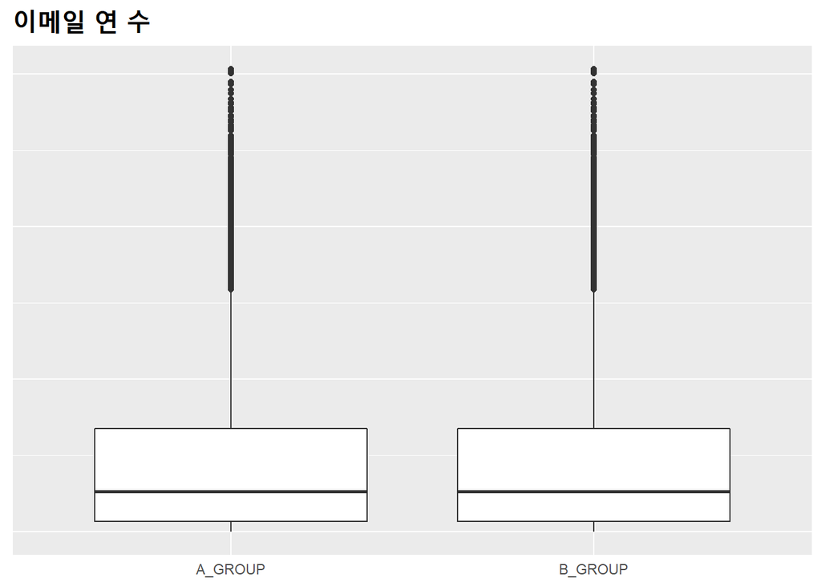

```r
# A_GROUP과 B_GROUP별 광고 이메일을 열어본 횟수
ggplot(adver, aes(x = type, y = open)) +
  geom_boxplot() +
  labs(title = "이메일 연 수") +
  theme(title = element_text(size = 15, face = "bold"),
        axis.ticks = element_blank(),
        axis.title = element_blank(),
        axis.text.y = element_blank())
```

```r
t.test(A_GROUP$click, B_GROUP$click)
```

```
##
##  Welch Two Sample t-test
##
## data:  A_GROUP$click and B_GROUP$click
## t = -42.204, df = 29470, p-value < 2.2e-16
## alternative hypothesis: true difference in means is not equal to 0
## 95 percent confidence interval:
##  -25.42244 -23.16589
## sample estimates:
## mean of x mean of y
##  24.59339  48.88755
```

- A_GROUP과 B_GROUP의 광고 광고 클릭 횟수는 평균적으로 차이가 있다

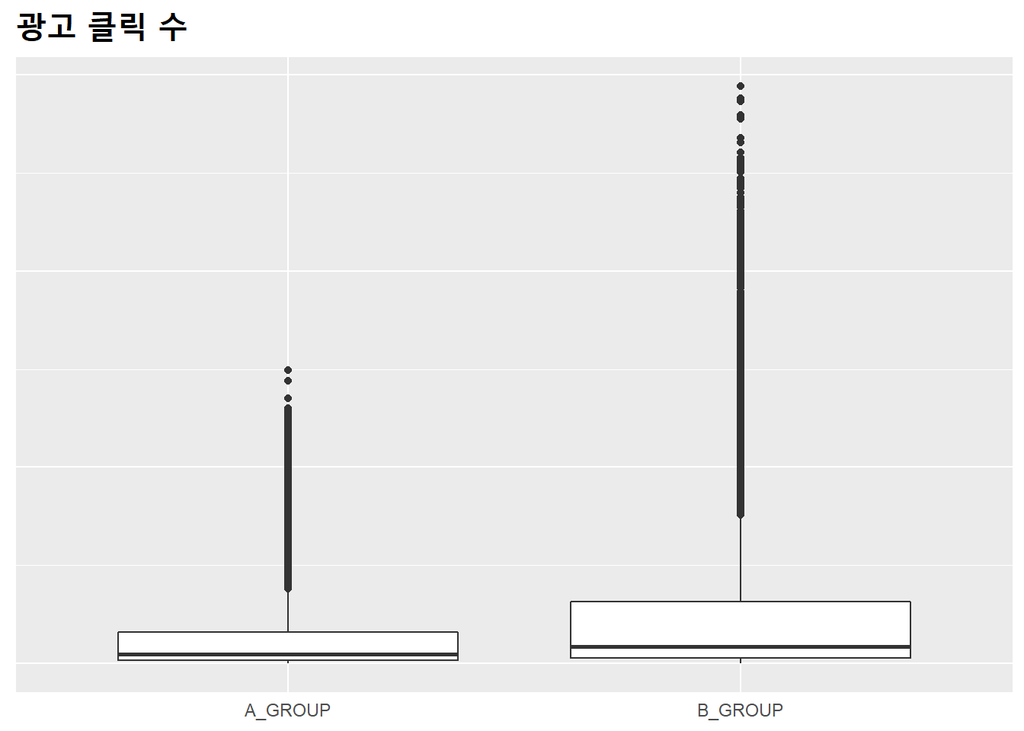

```r
# A_GROUP과 B_GROUP별 광고를 클릭해본 횟수
ggplot(adver, aes(x = type, y = click)) +
  geom_boxplot() +
  labs(title = "광고 클릭 수") +
  theme(title = element_text(size = 15, face = "bold"),
        axis.ticks = element_blank(),
        axis.title = element_blank(),
        axis.text.y = element_blank())
```

- A_GROUP보다 B_GROUP의 광고 클릭 횟수가 더 많음 => B_GROUP이 긍정적 결과

```r
t.test(A_GROUP$conversion, B_GROUP$conversion)
```

```
##
##  Welch Two Sample t-test
##
## data:  A_GROUP$conversion and B_GROUP$conversion
## t = -56.007, df = 22770, p-value < 2.2e-16
## alternative hypothesis: true difference in means is not equal to 0
## 95 percent confidence interval:
##  -1.90929 -1.78017
## sample estimates:
## mean of x mean of y
## 0.5583069 2.4030369
```

- A_GROUP과 B_GROUP의 광고 구매 전환 횟수는 평균적으로 차이가 있다

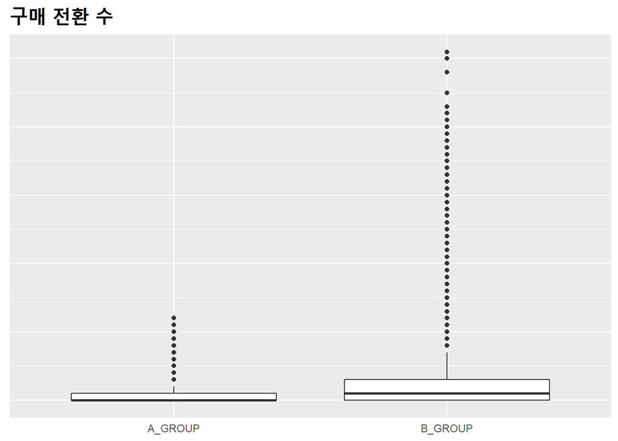

```r
# A_GROUP과 B_GROUP별 구매 전환 횟수
ggplot(adver, aes(x = type, y = conversion)) +
  geom_boxplot() +
  labs(title = "구매 전환 수") +
  theme(title = element_text(size = 15, face = "bold"),
        axis.ticks = element_blank(),
        axis.title = element_blank(),
        axis.text.y = element_blank())
```

- A_GROUP보다 B_GROUP의 구매 전환 횟수가 더 많음 => B_GROUP이 긍정적 결과

#### 경기도 추출하기

##### 경기도의 A_GROUP / B_GROUP 추출하기

```r
kyungki <- adver[adver$city1 == "경기도",]
kyungki_A <- kyungki[kyungki$type == "A_GROUP",]
kyungki_B <- kyungki[kyungki$type == "B_GROUP",]
dim(kyungki_A) ; dim(kyungki_B)
```

```
## [1] 2728    9
```

```
## [1] 2728    9
```

##### 정규성 검정

```r
shapiro.test(kyungki_A$open)
```

```
##
##  Shapiro-Wilk normality test
##
## data:  kyungki_A$open
## W = 0.89335, p-value < 2.2e-16
```

- 경기도의 A_GROUP의 이메일 확인의 분포는 정규성X

```r
shapiro.test(kyungki_B$open)
```

```
##
##  Shapiro-Wilk normality test
##
## data:  kyungki_B$open
## W = 0.89335, p-value < 2.2e-16
```

- 경기도의 B_GROUP의 이메일 확인의 분포는 정규성X
- 경기도의 A_GROUP, B_GROUP둘다 정규성X => wilcox.test() (귀무가설 : 두 집단 평균의 차이는 없다)

```r
leveneTest(y = kyungki$open, group = factor(kyungki$type))
```

```
## Levene's Test for Homogeneity of Variance (center = median)
##         Df F value Pr(>F)
## group    1       0      1
##       5454
```

- 경기도의 A_GROUP과 B_GROUP간 등분산성

```r
wilcox.test(open ~ type, kyungki)
```

```
##
##  Wilcoxon rank sum test with continuity correction
##
## data:  open by type
## W = 3720992, p-value = 1
## alternative hypothesis: true location shift is not equal to 0
```

- 경기도의 A_GROUP, B_GROUP간 평균의 차이 없다.

#### raster 패키지를 이용하여 대한민국 지도 그리기

getData(name, country, level) - name : “GADM” (https://gadm.org/index.html) - level : (0 : 국가 / 1 : 시도 / 2 : 시군구)

```r
library(raster)
```

- 국가

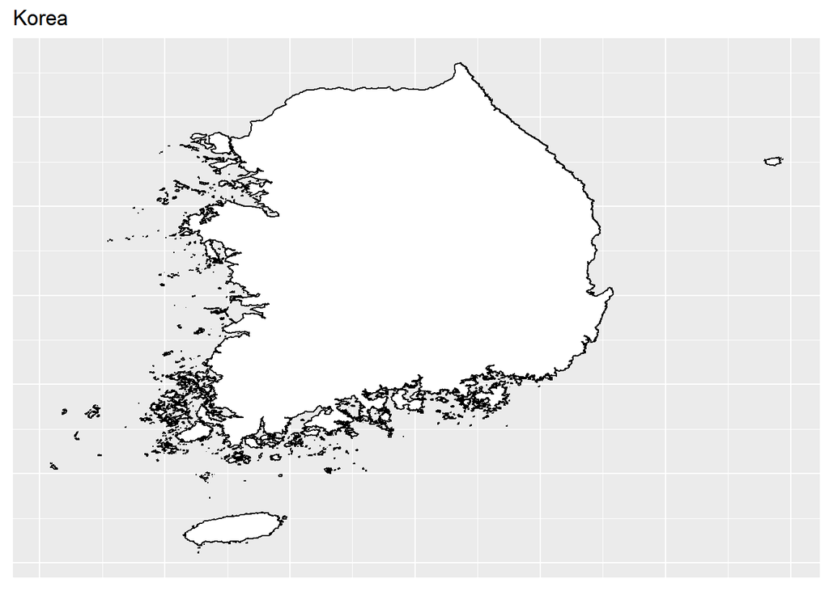

```r
korea = getData(name = "GADM",
                country = "kor",
                level = 0)
p1 <- ggplot(korea)
p1 +  geom_polygon(aes(x = long, y = lat, group = group),
                   fill = "white", color = "black") +
  labs(title = "Korea") +
  theme(axis.ticks = element_blank(),
        axis.title = element_blank(),
        axis.text = element_blank())
```

korea$GID_0 : 세자리 영문 코드 korea$NAME_0 : 전체 영문 이름

- 시/도

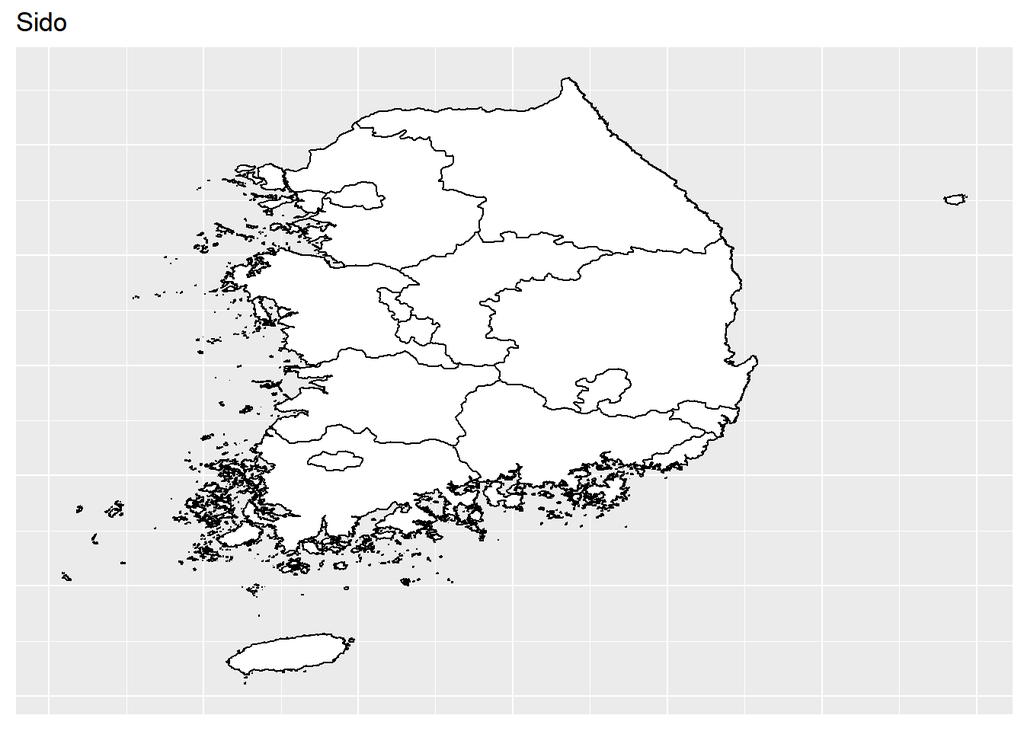

```r
korea_sido = getData(name = "GADM",
                     country = "kor",
                     level = 1)
p2 <- ggplot(korea_sido)
p2 + labs(title = "Sido") +
  geom_polygon(aes(x = long, y = lat, group = group),
               fill = "white", color = "black") +
  theme(axis.ticks = element_blank(),
        axis.title = element_blank(),
        axis.text = element_blank())
```

korea_sido$GID_1 : 시/도 영문 코드 korea_sido$NAME_1 : 시/도 영문 이름 korea_sido$VARNAME_1 : 언어별 시/도 이름 korea_sido$NL_NAME_1 : 시/도 한자 이름 korea_sido$TYPE_1 : 시/도 유형 (도/광역시/특별시) korea_sido$ENGTYPE_1 : 시/도 영문 유형 (Metropolitan City / Province / …) korea_sido$HASC_1 : 시/도의 짧은 코드

- 시/군/구

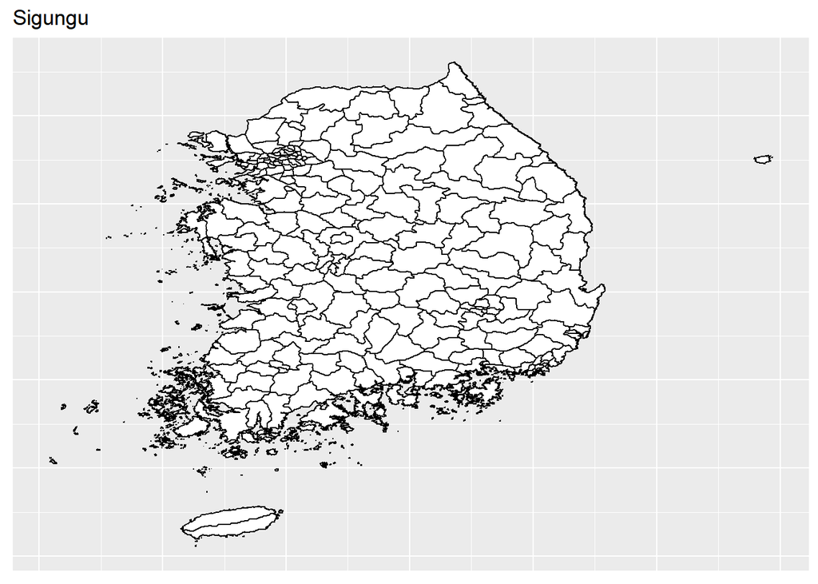

```r
korea_sigungu = getData(name = "GADM",
                        country = "kor",
                        level = 2)
p3 <- ggplot(korea_sigungu)
p3 + geom_polygon(aes(x = long, y = lat, group = group),
                  fill = "white", color = "black") +
  labs(title = "Sigungu") +
  theme(axis.ticks = element_blank(),
        axis.title = element_blank(),
        axis.text = element_blank())
```

korea_sigungu$NAME_1 : 시군구 소속 시도 (Seoul / Busan / ...) korea_sigungu$NAME_2 : 시군구 영문 이름

##### 서울에 속한 구

```r
seoul = korea_sigungu[korea_sigungu$NAME_1=="Seoul",]
```

```r
head(seoul$GID_2)  # 시/군/구 코드
```

```
## [1] "KOR.16.1_1" "KOR.16.2_1" "KOR.16.3_1" "KOR.16.4_1" "KOR.16.5_1"
## [6] "KOR.16.6_1"
```

```r
head(seoul$NAME_2)  # 시/군/구 영문 이름
```

```
## [1] "Dobong"      "Dong-daemun" "Dongjak"     "Eun-pyeong"  "Gandong"
## [6] "Gangbuk"
```

```r
# seoul$VARNAME_2  # 언어별 시/군/구 이름
head(seoul$NL_NAME_2)  # 시/군/구 한자 이름
```

```
## [1] "도봉구| 道峰區"     "동대문구| 東大門區" "동작구| 銅雀區"
## [4] "은평구| 恩平區"     "강동구| 江東區"     "강북구| 江北區"
```

```r
head(seoul$TYPE_2)  # 시/군/구 유형
```

```
## [1] "Gu" "Gu" "Gu" "Gu" "Gu" "Gu"
```

```r
head(seoul$ENGTYPE_2)  # 시/군/구별 영문 유형
```

```
## [1] "District" "District" "District" "District" "District" "District"
```

```r
# seoul$HASC_2  # 짧은 유형의 시군구 코드
```

```r
korea_sido = getData(name = "GADM",
                     country = "kor",
                     level = 1)
korea_sido@data
```

```
##    GID_0      NAME_0    GID_1            NAME_1
## 1    KOR South Korea  KOR.1_1             Busan
## 10   KOR South Korea  KOR.2_1 Chungcheongbuk-do
## 11   KOR South Korea  KOR.3_1 Chungcheongnam-do
## 12   KOR South Korea  KOR.4_1             Daegu
## 13   KOR South Korea  KOR.5_1           Daejeon
## 14   KOR South Korea  KOR.6_1        Gangwon-do
## 15   KOR South Korea  KOR.7_1           Gwangju
## 16   KOR South Korea  KOR.8_1       Gyeonggi-do
## 17   KOR South Korea  KOR.9_1  Gyeongsangbuk-do
## 2    KOR South Korea KOR.10_1  Gyeongsangnam-do
## 3    KOR South Korea KOR.11_1           Incheon
## 4    KOR South Korea KOR.12_1              Jeju
## 5    KOR South Korea KOR.13_1      Jeollabuk-do
## 6    KOR South Korea KOR.14_1      Jeollanam-do
```

[output cut: 57 more lines]

- 지역별로 두 집단에 대한 성과 분석을 한 결과 차이가 있다면 RESULT = 1
- 차이가 없다면 RESULT = 0

```r
(sido_key = data.frame(NAME_1 = korea_sido$NAME_1,
                      KOR = c("부산광역시", "충청북도", "충청남도", "대구광역시",
                              "대전광역시", "강원도", "광주광역시", "경기도",
                              "경상북도", "경상남도", "인천광역시",
                              "제주특별자치도", "전라북도", "전라남도",
                              "세종특별자치시", "서울특별시", "울산광역시"),
                      RESULT = 1))
```

```
##               NAME_1            KOR RESULT
## 1              Busan     부산광역시      1
## 2  Chungcheongbuk-do       충청북도      1
## 3  Chungcheongnam-do       충청남도      1
## 4              Daegu     대구광역시      1
## 5            Daejeon     대전광역시      1
## 6         Gangwon-do         강원도      1
## 7            Gwangju     광주광역시      1
## 8        Gyeonggi-do         경기도      1
## 9   Gyeongsangbuk-do       경상북도      1
## 10  Gyeongsangnam-do       경상남도      1
## 11           Incheon     인천광역시      1
## 12              Jeju 제주특별자치도      1
## 13      Jeollabuk-do       전라북도      1
## 14      Jeollanam-do       전라남도      1
## 15            Sejong 세종특별자치시      1
## 16             Seoul     서울특별시      1
## 17             Ulsan     울산광역시      1
```

```r
(korea_sido@data$id = rownames(korea_sido@data))
```

```
##  [1] "1"  "10" "11" "12" "13" "14" "15" "16" "17" "2"  "3"  "4"  "5"  "6"  "7"
## [16] "8"  "9"
```

```r
(korea_sido@data = merge(korea_sido@data, sido_key, by = "NAME_1"))
```

```
##               NAME_1 GID_0      NAME_0    GID_1
## 1              Busan   KOR South Korea  KOR.1_1
## 2  Chungcheongbuk-do   KOR South Korea  KOR.2_1
## 3  Chungcheongnam-do   KOR South Korea  KOR.3_1
## 4              Daegu   KOR South Korea  KOR.4_1
## 5            Daejeon   KOR South Korea  KOR.5_1
## 6         Gangwon-do   KOR South Korea  KOR.6_1
## 7            Gwangju   KOR South Korea  KOR.7_1
## 8        Gyeonggi-do   KOR South Korea  KOR.8_1
## 9   Gyeongsangbuk-do   KOR South Korea  KOR.9_1
## 10  Gyeongsangnam-do   KOR South Korea KOR.10_1
## 11           Incheon   KOR South Korea KOR.11_1
## 12              Jeju   KOR South Korea KOR.12_1
## 13      Jeollabuk-do   KOR South Korea KOR.13_1
## 14      Jeollanam-do   KOR South Korea KOR.14_1
```

[output cut: 57 more lines]

```r
(koreaDf = fortify(korea_sido))
(koreaDf = merge(koreaDf, korea_sido@data, by = "id"))
```

[output not shown]

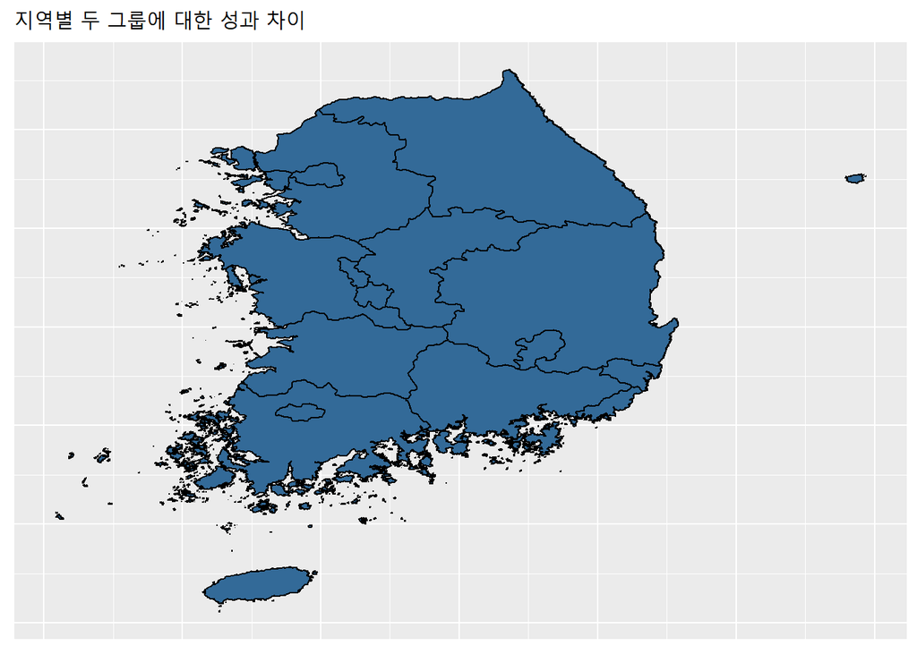

```r
ggplot() +
   geom_polygon(data = koreaDf, aes(x = long, y = lat, group = group, fill = RESULT),
                color = "black") +
 labs(title = "지역별 두 그룹에 대한 성과 차이") +
   theme(legend.position = "none",
         axis.ticks = element_blank(),
         axis.title = element_blank(),
         axis.text = element_blank())
```